# A Simple Introduction to Machine Learning

Emma Stubington

10/03/2020

## Load Data

Make sure the following packages are installed `("kernlab","randomForest","caret","e1071","ellipse")`

The data can be downloaded from https://wiki.cancerimagingarchive.net/display/Public/Head-Neck-PET-CT.

*Vallières, M. et al. Radiomics strategies for risk assessment of tumour failure in head-and-neck cancer. Sci Rep 7, 10117 (2017). doi: 10.1038/s41598-017-10371-5*

The original study **“Radiomics strategies for risk assessment of tumour failure in head-and-neck cancer”** investigated prediction models to predict locoregional recurrences, distant metastases and overall survival using clinical variables and radiomic data (*radiomics* is a method that extracts large amount of features from radiographic medical images using data-characterisation algorithm, examples include tumour intensity, texture and shape).

The study found that models using clinical variables only were better for overall survival predictions. They found the the clinical variables that predited it best were *Age, H&N type, T-Stage and N-Stage*. Here we use a simplified version of the dataset that contains the following variables:

- Age
- Primary Site
- Tstage
- NStage
- Suvival

Variable selection is an important stage of any ML problem and can prevent overfitting occurring. Variable selection methods include:

- Principal component analysis
- Correlation analysis
- Exploratory factor analysis
- Multicollinearity
- Backward/Forward elimination.

Here we will skip this step by using the selected variables from the above paper.

```r
# Download the data
dataset <- read_excel("SimplifiedHNData.xlsx")
# Remove Sex and Patient Number
dataset<-dataset[,3:7]
```

## Pre-processing: cleaning the data

Here a lot of the data cleaning has been done already as we are using data from a previous study. Patients from the study that had missing data or needed to be excluded have been.

However we need to make sure we are correctly modelling each variable. Here we will use three data types:

- Continuous: `Age`
- Categorigal: `PrimarySite`
- Ordered categorigal: `TSite` and `NSite`

Convert `age` to numeric

Convert `PrimarySite` and `Death` to factor

```
## [1] Larynx      Nasopharynx Oropharynx  unknown     Hypopharynx
## Levels: Hypopharynx Larynx Nasopharynx Oropharynx unknown
```

Convert `TStage` and `NStage` to ordered. Here we have simplified the staging info somewhat and assumed that Tx (tumour can’t be measured) comes before T1, we have also assumed T4<T4a<T4b which again is not strictly true.

```
## [1] T3  T1  T4  T2  Tx  T4b T4a
## Levels: Tx < T1 < T2 < T3 < T4 < T4a < T4b
```

```
## [1] N0  N1  N2b N2c N3  N2a N2  N3b
## Levels: N0 < N1 < N2 < N2a < N2b < N2c < N3 < N3b
```

Recheck the format each of the variables.

```r
str(dataset)
```

```
## Classes 'tbl_df', 'tbl' and 'data.frame':    298 obs. of  5 variables:
##  $ Age        : num  79 41 75 53 74 53 62 61 59 79 ...
##  $ PrimarySite: Factor w/ 5 levels "Hypopharynx",..: 2 3 2 3 3 3 4 4 2 4 ...
##  $ TStage     : Ord.factor w/ 7 levels "Tx"<"T1"<"T2"<..: 4 2 4 4 2 2 5 3 4 3 ...
##  $ NStage     : Ord.factor w/ 8 levels "N0"<"N1"<"N2"<..: 1 2 5 2 2 5 5 5 1 5 ...
##  $ Death      : Factor w/ 2 levels "0","1": 1 1 2 1 2 1 2 1 1 1 ...
```

We now have the data in the correct format to build our model.

## Create a training set

We now need to split the dataset into two, *80%* of which we will use to train our models and *20%* that we will hold back as a test (validation) dataset.

```r
# create a list of 80% of the rows in the original dataset we can use for training
set.seed(645) # This is so we can re-run this and get the same again
validation_index <- createDataPartition(dataset$Age, p=0.80, list=FALSE)
# select 20% of the data for testing
test_data <- dataset[-validation_index,]
# use the remaining 80% of data to train the models
train_data <- dataset[validation_index,]
```

You now have two datasets:

1. The training set `train_data`, to build our models with
2. The test set `test_data`, to validate our models with at the end.

## Summary statistics

It is useful to understand the dataset and the variables it contains. Here we will use the training dataset for our summary statistics.

```r
#dimensions of the dataset
dim(train_data)
```

```
## [1] 241   5
```

```r
#Look at the data
head(train_data)
```

```
## # A tibble: 6 x 5
##     Age PrimarySite TStage NStage Death
##   <dbl> <fct>       <ord>  <ord>  <fct>
## 1    79 Larynx      T3     N0     0
## 2    41 Nasopharynx T1     N1     0
## 3    75 Larynx      T3     N2b    1
## 4    53 Nasopharynx T3     N1     0
## 5    62 Oropharynx  T4     N2b    1
## 6    61 Oropharynx  T2     N2b    0
```

```r
#what levels are in the data?
levels(train_data$PrimarySite)
```

```
## [1] "Hypopharynx" "Larynx"      "Nasopharynx" "Oropharynx"  "unknown"
```

```r
#Summarise the class distribution
percentage <- prop.table(table(train_data$PrimarySite)) * 100
cbind(freq=table(train_data$PrimarySite), percentage=percentage)
```

```
##             freq percentage
## Hypopharynx   11   4.564315
## Larynx        34  14.107884
## Nasopharynx   21   8.713693
## Oropharynx   169  70.124481
## unknown        6   2.489627
```

```r
#Statistical summary
summary(train_data)
```

```
##       Age             PrimarySite  TStage       NStage   Death
##  Min.   :18.00   Hypopharynx: 11   Tx : 7   N2     :81   0:194
##  1st Qu.:57.00   Larynx     : 34   T1 :31   N0     :47   1: 47
##  Median :63.00   Nasopharynx: 21   T2 :93   N1     :37
##  Mean   :63.46   Oropharynx :169   T3 :72   N2b    :33
##  3rd Qu.:70.00   unknown    :  6   T4 :18   N2c    :21
##  Max.   :90.00                     T4a:14   N3     :14
##                                    T4b: 6   (Other): 8
```

## Visualise the data

We can create plots to understand the data further.

- Univariate plots to better understand each attribute.
- Multivariate plots to better understand the relationships between attributes.

We can split our data into inputs (`x`) and outputs (`y`), where output(s) are what we are trying to predict and the inputs are the variables we are using to predict `y`.

Here we will try and predict the survival of a patient.

```r
# split input and output
x <- train_data[,1:4]
y <- train_data[,5]
```

Univariate plots are plots of individual variables Look at the distribution of the continuous variables

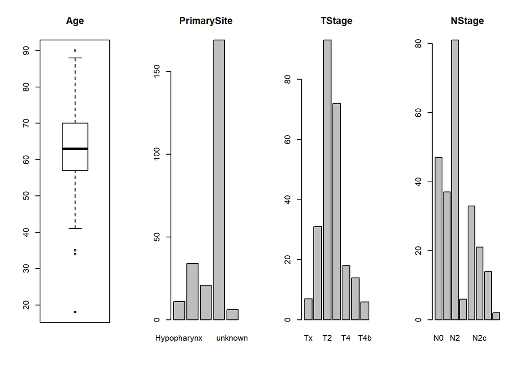

```r
# boxplot for each attribute on one image
par(mfrow=c(1,4))
 boxplot(x[,1], main=names(train_data)[1])
 for(i in 2:4) {
plot(x[,i], main=names(train_data)[i])
 }
```

We can now use multivariate plots to look at the relationship between our variables. These look quite messy because we have mainly categorigal variables.

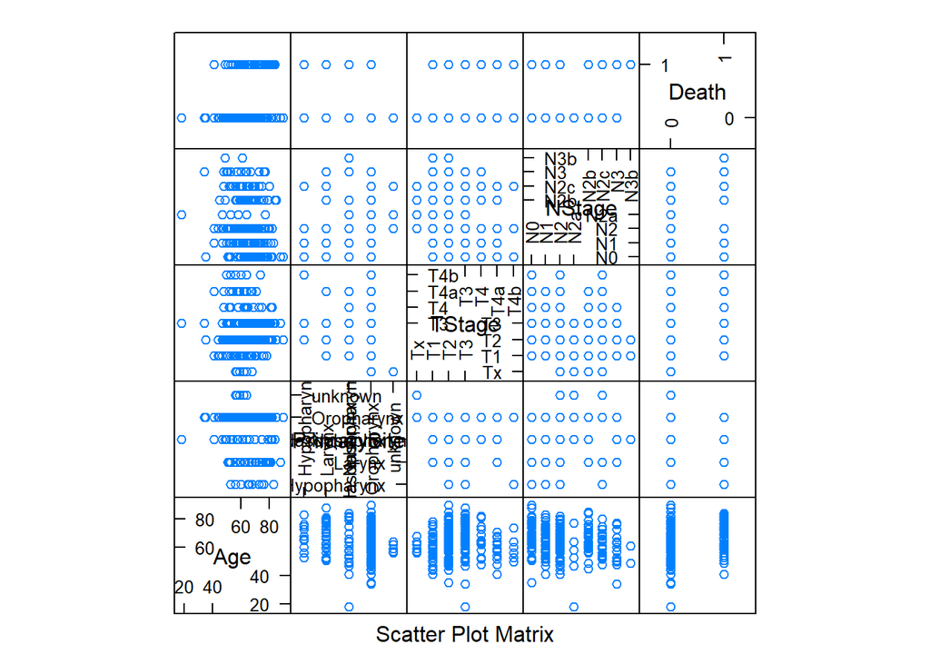

```r
# scatterplot matrix
featurePlot(x=x, y=y, plot="pairs")
```

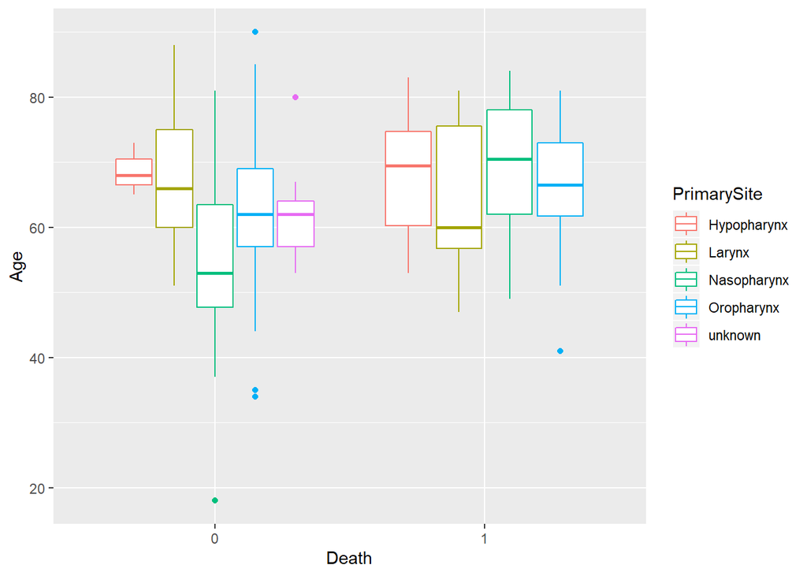

```r
ggplot(data = dataset, aes(x = factor(Death), y = Age, colour = PrimarySite)) + geom_boxplot() +
  xlab("Death")
```

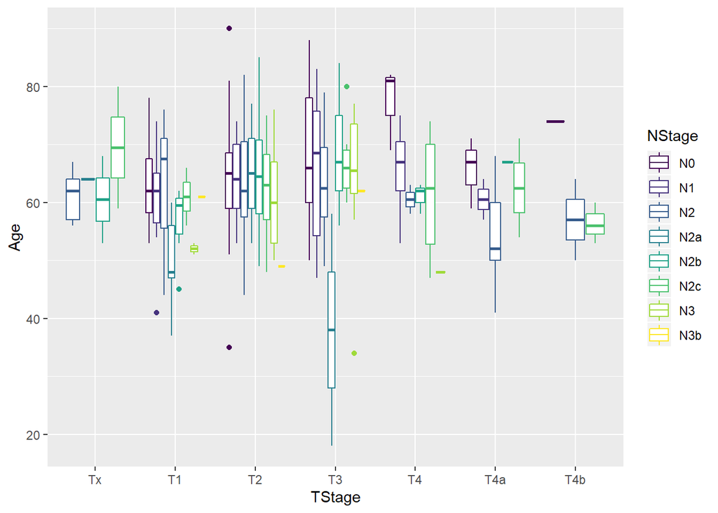

```r
ggplot(data = dataset, aes(x = TStage, y = Age, colour = NStage)) + geom_boxplot() +
  xlab("TStage")
```

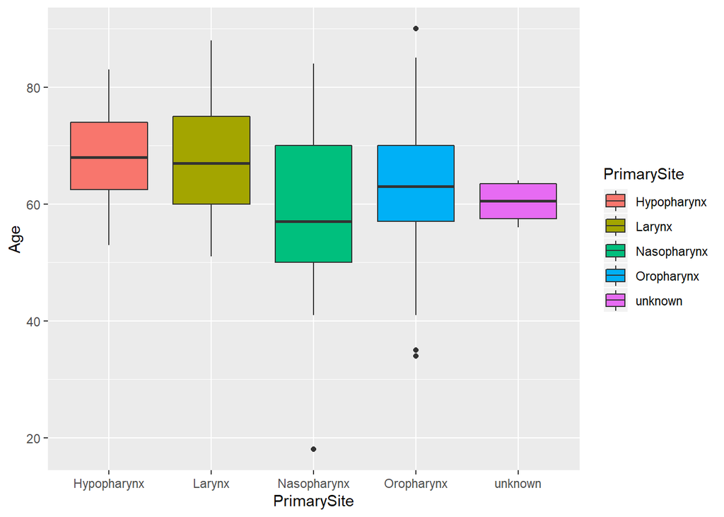

```r
 qplot(PrimarySite, Age, data=train_data,
      fill=PrimarySite,
      geom=c("boxplot"))
```

```r
 tapply(train_data$Age, train_data$PrimarySite, summary)
```

```
## $Hypopharynx
##    Min. 1st Qu.  Median    Mean 3rd Qu.    Max.
##    53.0    62.5    68.0    68.0    74.0    83.0
##
## $Larynx
##    Min. 1st Qu.  Median    Mean 3rd Qu.    Max.
##   51.00   60.00   67.00   67.35   75.00   88.00
##
## $Nasopharynx
##    Min. 1st Qu.  Median    Mean 3rd Qu.    Max.
##   18.00   50.00   57.00   59.14   70.00   84.00
##
## $Oropharynx
##    Min. 1st Qu.  Median    Mean 3rd Qu.    Max.
##   34.00   57.00   63.00   63.02   70.00   90.00
##
## $unknown
##    Min. 1st Qu.  Median    Mean 3rd Qu.    Max.
##   56.00   57.50   60.50   60.33   63.50   64.00
```

## Run some algorithms

Here we want to create our models and then test their accuracy on unseen data, our test set, `test_data`. To do this we:

1. Set up a test with k-fold cross validation
2. Build 5 different models to predict Survival
3. Select our best model

## k-fold crossvalidation

Cross-validation is a resampling procedure used to evaluate machine learning models, it is particularly useful when we have a limited data sample.

`k` refers to the numeber of groups that the data will be split up into.

Here we use `k=10`, 10-fold cross validation.

1. Randomly shuffle the dataset
2. Split the data into `k` groups
3. For each group:
   - Assign a single group as the hold group (each group will be a hold set once)
   - The remaining groups are the training groups
   - Fit a model on the training sets and evaluate it on the hold group
   - Keep the evaluation score and discard the model
4. The skill of the model is then summarised using the sample of model evaluation scores

Each observation in the (training) dataset stays in its assigned group throughout the process. In this way, each sample is left out of the model once and used to train the model `k-1` times.

Be careful here, we again have a training and a test set. The `k` groups are only taken from `train_data`.

Here we will assess our models according to accuracy.

```r
# Run algorithms using 10-fold cross validation
control <- trainControl(method="cv", number=10)
metric <- "Accuracy"
```